# Analysis of OkCupid Dating Profiles

# Introduction

## Context

OkCupid is a free online dating app where users have profiles that must have at least one picture and could possibly have some prompt questions that ask about their life style. The data was scraped off the app with permission from app co-founders.

## Dataset

The data set itself found on github: https://github.com/rudeboybert/JSE_OkCupid?tab=readme-ov-file. The data is spread across two seperate csv files one called profiles_revised.csv.zip and essays_revised_and_shuffled.zip. The profiles_revised.csv contains profile data for 59,946 people in San Francisco. This file contains mostly the lifestyle and demographics details about the users. The fields along with descriptions are as follows:

```
age: age of user with random noise added for anonymization

body_type- rather not say, thin, overweight, skinny, average, fit, athletic, jacked, a little extra, curvy, full figured, used up

diet- mostly/strictly; anything, vegetarian, vegan, kosher, halal, other

drinks- very often, often, socially, rarely, desperately, not at all

drugs- never, sometimes, often

education- graduated from, working on, dropped out of; high school, two-year college, university, masters program, law school, med school, Ph.D program, space camp

ethnicity- Asian, middle eastern, black, native American, indian, pacific islander, Hispanic/latin, white, other

height- inches

income- (US $, -1 means rather not say) -1, 20000, 30000, 40000, 50000, 60000 70000, 80000, 100000, 150000, 250000, 500000, 1000000,

job- student, art/music/writing, banking/finance, administration, technology, construction, education, entertainment/media, management, hospitality, law, medicine, military, politics/government, sales/marketing, science/engineering, transportation, unemployed, other, rather not say, retire

offspring- has a kid, has kids, doesnt have a kid, doesn't want kids; ,and/,but might want them, wants them, doesnt want any, doesnt want more

orientation- straight, gay, bisexual

pets- has dogs, likes dogs, dislikes dogs; and has cats, likes cats, dislikes cats

religion- agnosticism, atheism, Christianity, Judaism, Catholicism, Islam, Hinduism, Buddhism, Other; and very serious about it, and somewhat serious about it, but not too serious about it, and laughing about it

sex- m, f

sign- aquarius, pices, aries, Taurus, Gemini, cancer, leo, virgo, libra, scorpio, saggitarius, Capricorn; but it doesn’t matter, and it matters a lot, and it’s fun to think about

smokes- yes, sometimes, when drinking, trying to quit, no

speaks- English (fluently, okay, poorly). Afrikaans, Albanian, Arabic, Armenian, Basque, Belarusan, Bengali, Breton, Bulgarian, Catalan, Cebuano, Chechen, Chinese, C++, Croatian, Czech, Danish, Dutch, Esperanto, Estonian, Farsi, Finnish, French, Frisian, Georgian, German, Greek, Gujarati, Ancient Greek, Hawaiian, Hebrew, Hindi, Hungarian, Icelandic, Ilongo, Indonesian, Irish, Italian, Japanese, Khmer, Korean, Latin, Latvian, LISP, Lithuanian, Malay, Maori, Mongolian, Norwegian, Occitan, Other, Persian, Polish, Portuguese, Romanian, Rotuman, Russian, Sanskrit, Sardinian, Serbian, Sign Language, Slovak, Slovenian, Spanish, Swahili, Swedish, Tagalog, Tamil, Thai, Tibetan, Turkish, Ukranian, Urdu, Vietnamese, Welsh, Yiddish (fluently, okay, poorly)

status- single, seeing someone, married, in an open relationship
```

For the second file which is essays_revised_and_shuffled.csv contains responses to the essay prompts of the app:

```
essay0- My self summary
essay1- What I’m doing with my life
essay2- I’m really good at
essay3- The first thing people usually notice about me
essay4- Favorite books, movies, show, music, and food
essay5- The six things I could never do without
essay6- I spend a lot of time thinking about
essay7- On a typical Friday night I am
essay8- The most private thing I am willing to admit
essay9- You should message me if...
```

## Data Cleaning

The essay portion of the data set was anonymized by making not matching it up with the profile data from the first csv file. So row 1 in the profiles csv does not mean row 1 in the essay portion to allow for the privacy of people. Also a noise factor was added to ages to once again maintain people's privacy. Also any links to the individuals social media accoutns such as facebook, instagram, twitter, etc. were removed.

# Sample of Rows From Profile Data

```python
import pandas as pd
import numpy as np
import re
import nltk
from nltk.corpus import stopwords
from nltk.tokenize import word_tokenize
from sklearn.decomposition import LatentDirichletAllocation
from sklearn.decomposition import PCA
from sklearn.feature_extraction.text import CountVectorizer, TfidfVectorizer
import gensim
from gensim.utils import simple_preprocess
import gensim.corpora as corpora
import matplotlib.pyplot as plt
from wordcloud import WordCloud
# Load the datasets
profiles_df = pd.read_csv('profiles_revised.csv')
essays_df = pd.read_csv('essays_revised_and_shuffled.csv')


# Rename the columns in the essays dataframe
essays_df.columns = [
    "My self summary",
    "What I’m doing with my life",
    "I’m really good at",
    "The first thing people usually notice about me",
    "Favorite books, movies, show, music, and food",
    "The six things I could never do without",
    "I spend a lot of time thinking about",
    "On a typical Friday night I am",
    "The most private thing I am willing to admit",
    "You should message me if..."
]

# Display the first couple of rows of both datasets
print("Profiles DataFrame Head:")
display(profiles_df.head())

print("\n")
print("\nEssays DataFrame Head:")
display(essays_df.head())
```

```
Profiles DataFrame Head:
```

|  | age | body_type | diet | drinks | drugs | education | ethnicity | height | income | job | offspring | orientation | pets | religion | sex | sign | smokes | speaks | status |
| --- | --- | --- | --- | --- | --- | --- | --- | --- | --- | --- | --- | --- | --- | --- | --- | --- | --- | --- | --- |
| 0 | 22 | a little extra | strictly anything | socially | never | working on college/university | asian, white | 75.0 | -1 | transportation | doesn&rsquo;t have kids, but might want them | straight | likes dogs and likes cats | agnosticism and very serious about it | m | gemini | sometimes | english | single |
| 1 | 36 | average | mostly other | often | sometimes | working on space camp | white | 70.0 | 80000 | hospitality / travel | doesn&rsquo;t have kids, but might want them | straight | likes dogs and likes cats | agnosticism but not too serious about it | m | cancer | no | english (fluently), spanish (poorly), french (... | single |
| 2 | 37 | thin | anything | socially | NaN | graduated from masters program | NaN | 68.0 | -1 | NaN | NaN | straight | has cats | NaN | m | pisces but it doesn&rsquo;t matter | no | english, french, c++ | available |
| 3 | 22 | thin | vegetarian | socially | NaN | working on college/university | white | 71.0 | 20000 | student | doesn&rsquo;t want kids | straight | likes cats | NaN | m | pisces | no | english, german (poorly) | single |
| 4 | 30 | athletic | NaN | socially | never | graduated from college/university | asian, black, other | 66.0 | -1 | artistic / musical / writer | NaN | straight | likes dogs and likes cats | NaN | m | aquarius | no | english | single |

```
Essays DataFrame Head:
```

|  | My self summary | What I’m doing with my life | I’m really good at | The first thing people usually notice about me | Favorite books, movies, show, music, and food | The six things I could never do without | I spend a lot of time thinking about | On a typical Friday night I am | The most private thing I am willing to admit | You should message me if... |
| --- | --- | --- | --- | --- | --- | --- | --- | --- | --- | --- |
| 0 | well hi there. my mantra this year is "<a clas... | working, exploring the world, and meeting cool... | playing the <a class="ilink" href="/interests?... | my laugh (if i happen to be laughing (or playi... | way too many of each to count, so i'll just wr... | a piano<br />\nbig picture windows with panora... | adventures that i've yet to have | probably working late, then coming home to cra... | i named my roomba. philippe and i have had som... | -you believe that community is a gift from the... |
| 1 | NaN | NaN | NaN | NaN | NaN | NaN | NaN | NaN | NaN | NaN |
| 2 | musician / writer / programmer from the woods ... | working for startups, destroying dancefloors, ... | taking things apart and fixing them. cooking w... | NaN | my music collection is a little bit out of con... | lowpass filters, spanish rice, public radio, w... | cosmology and the fate of the universe. | "you can find me in the club" - curtis james j... | i've been skating for 6 years and only learned... | you need some money moved out of nigeria, or i... |
| 3 | nothing in this world can take the place of pe... | i'm committed full-time to my art practice. i ... | painting. observational comedy. finding cool s... | i'm tall. i don't know, you tell me... | artists- anselm kiefer, peter doig, edvard mun... | -art<br />\n<br />\n-tunes<br />\n<br />\n-npr... | -how i can keep evolving as an artist and pers... | either locked in the studio or out on the town! | i think terry gross' snort when she laughs is ... | i'm looking to find a good, kind-hearted woman... |
| 4 | i'm a sweet, sassy, easy going, low femme look... | i'm a public interest lawyer. i am passionate ... | creative cooking projects<br />\nhosting parti... | my curly hair and hopefully my sparkle. | a few favorites: movies + tv = woody allen; fe... | i could never do without love and community, a... | time with friends somewhere gorgeous and woods... | looking for love in all the wrong places. | sometimes i tend toward hyperbole. | you think i might be interesting and/or cute o... |

# Life Style Factors

The first set of guiding questions is about the life style factors that make up the distribution of users on the app. These factors can include diet, body type, education, drinking habits. This can be useful to see what the distribution of users on the app is and if there are any common life style tests.

## What is the Age Distribution on the App

```python
from IPython.display import IFrame

# Display the PDF
IFrame("AgeDist.pdf", width=900, height=800)
```

[interactive chart not shown]

The age distribution shows that majority of the users on the app are young adults around the ages of 20-25. There is also a significant number of users around the age of 30. This gives us an understanding of the population that is more prone to using data apps and the age ranges of people that one can expect to meet. Also shows that if you are a young person this app can be a good place to meet people.

# What is the Distribution of Body Type, Diet, and Drinking Habits

## Body Type Distribution

```python
from IPython.display import IFrame

# Display the PDF
IFrame("Body.pdf", width=900, height=800)
```

[interactive chart not shown]

The distribution of body type shows that most people are either average probably meaning they do not do any extra work such going to the gym or some form of athletics. The next most common categories that are both similar are fit and athletic body types as these people either most likely go to the gym or participate in some form of sport. Furthermore, there may be a lifestyle link of diet for people that have more athletic / fit body types compared to those that do not.

## Diet Distribution

```python
from IPython.display import IFrame

# Display the PDF
IFrame("Diet.pdf", width=900, height=800)
```

[interactive chart not shown]

Looking at the distribution of diet it can be seen that people are very open with their diet in the sense that there are no dietary restictions. Of the dietary restrictions that come up vegetarian appears to be the most common. There does not appear to be any main concern of cultural differences when it coems to diet as most people are open to eating anything and thus probably willing to try out different cuisines.

## Drinking Habits

```python
from IPython.display import IFrame

# Display the PDF
IFrame("Drink.pdf", width=900, height=800)
```

[interactive chart not shown]

The distribution of drinking habits show that most people are social drinkers so this can involve meetups with friends, dates, or any other form of social activities. This category implies that people do not drink when they are by themseleves or daily heavy drinkers. There are mainly a dichotomy between social drinkers and those that do not drink or not very often. This shows that majority of the users are either into night life or social scenes where they drink such as parties.

# DemoGraphic Factors

These factors are more to stratify the users in terms of demographics such as education, income, and religous beliefs. This shows mostly status and and the personal beliefs of individual users on the app. Given the affluent city of San Francisco where this data was sourced from we can expect to see a higher income and probably higher levels of education among individuals. Furthermore, San Francisco and especially the tech community within it are known to not have a lot of religous views. Through the exploration of the data we can see if these claims are true and what we can expect to see of the users.

## What is the Education Distribution of Users on the App

```python
from IPython.display import IFrame

# Display the PDF
IFrame("Education.pdf", width=900, height=800)
```

[interactive chart not shown]

As per expected a large majority of users have completed post secondary education as this is expected given the cities thriving tech and science sectors. This goes to show that most users expect this to be the norm and have an education at a post secnodnary institution may be considered commonplace among these users. It can also be seen that large portion also have masters degree and this further cements the emphasize that users may place on education as a status given the region.

## What is the Income Distribution for Males and Females on the App

```python
from IPython.display import IFrame

# Display the PDF
IFrame("IncomeFemales.pdf", width=900, height=800)
```

[interactive chart not shown]

The clustering within the ditribution appears to be in the upper end range of 40 - 80k which with some women making 6 figures. This shows that as a big city with a thriving industry that women here may earn more. From the persepective of women they may be more independent in terms of dating due to having secure incomes.

```python
from IPython.display import IFrame

# Display the PDF
IFrame("IncomeMales.pdf", width=900, height=800)
```

[interactive chart not shown]

For males there is a similar clustering around the 50k range, however a larger portion make between 100k to 150k and this is presumably those that work in the tech sector as the salaries there are generally higher paying. This demographic shows that most male users are finacially well off and are in the upper regions of the income distribution relative to women. Users of this app may have a certain standard of living given their income ranges.

## What is the distribution of religion among users of the app

```python
from IPython.display import IFrame

# Display the PDF
IFrame("ReligionDist.pdf", width=900, height=800)
```

[interactive chart not shown]

As stated earlier the tech culture and steoreotype of San Francisco is that of generally non-religous folks that are laid back in terms of their spiritual beliefs. The large Null values underly that those that are spirtual or religous are avoidant of showing their beliefs due to this culture being prominent so they may hide them or practice in secret. The largest portions of users are agnostic or atheist followed by the next most common group being users that are christians.

# Text Mining Analysis of Users Essay Responses

## Analysis of Topics for Profiles Essays

The essay's are prompt questions labelled 0-9 which were shown earlier. Now we will analyze the topics that show up the most for each of these responses. This will allow use to analyze what are people most talking about and give an insight into interests and possilby personalities. Using this data we can guage what is an expected discussion among users of the app and where their interests lie.

```python
# import nltk
# nltk.download()

# from nltk.corpus import stopwords
# stop_words = set(stopwords.words('english'))
# print("Sample stopwords:", list(stop_words)[:10])
```

First the data must be loaded in and cleaned to remove social media links for privacy concerns as well removing html tags which frequently showed up and polluted the topics list if not cleaned.

```python
import pandas as pd
import numpy as np
import re
import nltk
from nltk.corpus import stopwords
from nltk.tokenize import word_tokenize
from sklearn.decomposition import LatentDirichletAllocation, PCA
from sklearn.feature_extraction.text import CountVectorizer, TfidfVectorizer
import gensim
from gensim.utils import simple_preprocess
import gensim.corpora as corpora
import matplotlib.pyplot as plt
from wordcloud import WordCloud
import seaborn as sns

# Ensure the NLTK data is available and load stopwords
nltk.download('stopwords')
stop_words = set(stopwords.words('english'))

# Load the first 1,000 rows of the essays data
essays_df = pd.read_csv('essays_revised_and_shuffled.csv', nrows=1000)
profiles_df = pd.read_csv('profiles_revised.csv', nrows=1000)

# Rename the columns in essays_df
essays_df.columns = [
    "My self summary",
    "What I’m doing with my life",
    "I’m really good at",
    "The first thing people usually notice about me",
    "Favorite books, movies, show, music, and food",
    "The six things I could never do without",
    "I spend a lot of time thinking about",
    "On a typical Friday night I am",
    "The most private thing I am willing to admit",
    "You should message me if..."
]

def clean_text(text):
    text = re.sub(r"http\S+", "", text)  # remove URLs
    text = re.sub(r"\S+@\S+", "", text)  # remove email addresses
    text = re.sub(r"<.*?>", "", text)  # remove HTML tags
    text = re.sub(r"[^A-Za-z\s]", "", text.lower())  # remove non-alphabets
    tokens = word_tokenize(text)  # tokenize
    tokens = [word for word in tokens if word not in stop_words]  # remove stopwords
    return " ".join(tokens)

# Check if the function works for a sample text
sample_text = "This is a test sentence to check the stop words."
print("Cleaned sample text:", clean_text(sample_text))

# Apply the cleaning function to each essay
for col in essays_df.columns:
    essays_df[col] = essays_df[col].apply(lambda x: clean_text(str(x)))

# Display the first few rows after cleaning
print(essays_df.head())

# Combine all essays into a single text for each user
essays_df['all_essays'] = essays_df.apply(lambda row: ' '.join(row.values.astype(str)), axis=1)

# Display the first few rows after combining essays
print(essays_df.head())
```

```
Cleaned sample text: test sentence check stop words
                                     My self summary  \
0  well hi mantra year classilink href interestsi...
1                                                nan
2  musician writer programmer woods montana dance...
3  nothing world take place persistence talent no...
4  im sweet sassy easy going low femme looking ro...

                         What I’m doing with my life  \
0  working exploring world meeting cool people al...
1                                                nan
2  working startups destroying dancefloors learni...
3  im committed fulltime art practice also underp...
4  im public interest lawyer passionate cooking e...

```

[output cut: 131 more lines]

```python
def sentences_to_words(sentences):
    for sentence in sentences:
        yield(simple_preprocess(str(sentence), deacc=True))

def remove_stopwords(texts):
    return [[word for word in simple_preprocess(str(doc)) if word not in stop_words] for doc in texts]

essays_text = essays_df['all_essays'].tolist()
essays_words = list(sentences_to_words(essays_text))
essays_words = remove_stopwords(essays_words)

# Create Dictionary
id2word = corpora.Dictionary(essays_words)

# Create Corpus
texts = essays_words

# Term Document Frequency
corpus = [id2word.doc2bow(text) for text in texts]
```

```python
# Reduce the number of topics and passes for faster processing
num_topics = 9
num_passes = 5
chunksize = 100

# Build LDA model
lda_model = gensim.models.LdaMulticore(
    corpus=corpus,
    id2word=id2word,
    num_topics=num_topics,
    random_state=100,
    chunksize=chunksize,
    passes=num_passes,
    per_word_topics=True
)

# Print the Keyword in the 5 topics
from pprint import pprint
pprint(lda_model.print_topics())
doc_lda = lda_model[corpus]
```

```
[(0,
  '0.014*"im" + 0.012*"love" + 0.009*"like" + 0.008*"good" + 0.008*"friends" + '
  '0.007*"music" + 0.007*"life" + 0.006*"things" + 0.006*"new" + 0.006*"time"'),
 (1,
  '0.022*"im" + 0.011*"like" + 0.011*"love" + 0.008*"good" + 0.007*"life" + '
  '0.007*"people" + 0.007*"nan" + 0.007*"music" + 0.007*"friends" + '
  '0.006*"time"'),
 (2,
  '0.015*"classilink" + 0.012*"href" + 0.011*"im" + 0.009*"like" + '
  '0.007*"love" + 0.006*"people" + 0.005*"music" + 0.005*"food" + 0.004*"good" '
  '+ 0.004*"friends"'),
 (3,
  '0.023*"nan" + 0.013*"im" + 0.011*"like" + 0.008*"love" + 0.007*"music" + '
  '0.006*"classilink" + 0.006*"good" + 0.005*"friends" + 0.005*"dont" + '
  '0.005*"href"'),
 (4,
  '0.009*"im" + 0.007*"like" + 0.005*"friends" + 0.004*"amp" + 0.004*"good" + '
  '0.003*"people" + 0.003*"music" + 0.003*"also" + 0.003*"love" + '
  '0.003*"things"'),
 (5,
  '0.011*"im" + 0.009*"like" + 0.006*"amp" + 0.005*"love" + 0.004*"food" + '
  '0.004*"good" + 0.004*"also" + 0.004*"things" + 0.004*"one" + '
  '0.003*"friends"'),
 (6,
  '0.016*"rg" + 0.014*"gr" + 0.008*"df" + 0.008*"sd" + 0.005*"sdf" + '
  '0.004*"love" + 0.004*"im" + 0.004*"like" + 0.004*"rth" + 0.004*"fsdf"'),
 (7,
  '0.009*"like" + 0.009*"im" + 0.007*"food" + 0.006*"friends" + 0.006*"good" + '
  '0.005*"time" + 0.004*"nan" + 0.004*"life" + 0.004*"love" + 0.004*"music"'),
 (8,
  '0.023*"im" + 0.010*"like" + 0.007*"love" + 0.007*"good" + 0.007*"people" + '
  '0.006*"classilink" + 0.006*"href" + 0.006*"music" + 0.006*"things" + '
  '0.005*"time"')]
```

```python
topic_names = {
    0: "Hobbies and Interests",
    1: "Personal Feelings",
    2: "Social Life",
    3: "Music and Movies",
    4: "Daily Activities",
    5: "Technology and Internet",
    6: "Relationships",
    7: "Work and Education",
    8: "Food and Drinks"
}

# Print the topics with names
for idx, topic in enumerate(topics):
    print(f"Topic {idx}: {topic_names[idx]}")
    print(topic)
    print("\n")
```

[output not shown]

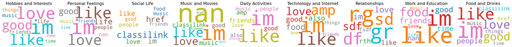

```python
# Plot the Word Clouds for each topic with names
cols = plt.cm.tab10.colors

cloud = WordCloud(stopwords=stopwords.words('english'),
                  background_color='white',
                  width=2500,
                  height=1800,
                  max_words=10,
                  colormap='tab10',
                  prefer_horizontal=1.0)

topics = lda_model.show_topics(formatted=False)
fig, axes = plt.subplots(1, 9, figsize=(27, 3), sharex=True, sharey=True)

for i, ax in enumerate(axes.flatten()):
    fig.add_subplot(ax)
    topic_words = dict(topics[i][1])
    cloud_img = cloud.generate_from_frequencies(topic_words).to_array()
    ax.imshow(cloud_img)
    ax.set_title(f'{topic_names[i]}', fontdict=dict(size=16))
    ax.axis('off')

plt.subplots_adjust(wspace=0, hspace=0)
plt.tight_layout()
plt.show()
```

Generally browsing through the most common words the main things people seem to talk about are their friends, music, and food. These things can be good openers for the converstaion and let you know more about other people. Furthermore, food may show up given that users are planning meetups. Also music and food can give insights into a persons likes and dislikes.

```python
# Get topic distributions for each document
topic_distributions = lda_model.get_document_topics(corpus, minimum_probability=0)
topic_matrix = gensim.matutils.corpus2dense(topic_distributions, num_terms=num_topics).T

# Convert topic distributions to a DataFrame
topic_df = pd.DataFrame(topic_matrix, columns=[f'Topic_{i}' for i in range(num_topics)])
topic_df['Dominant_Topic'] = topic_df.idxmax(axis=1)
topic_df['Dominant_Topic'] = topic_df['Dominant_Topic'].apply(lambda x: int(x.split('_')[1]))

# Map topic indices to topic names
topic_df['Dominant_Topic_Name'] = topic_df['Dominant_Topic'].map(topic_names)

# Display the first few rows
print(topic_df.head())
```

```
    Topic_0   Topic_1   Topic_2   Topic_3   Topic_4   Topic_5   Topic_6  \
0  0.000759  0.321420  0.000759  0.673269  0.000759  0.000758  0.000758
1  0.010102  0.010104  0.010102  0.919183  0.010102  0.010102  0.010101
2  0.000702  0.994386  0.000702  0.000702  0.000702  0.000702  0.000702
3  0.000207  0.000207  0.998344  0.000207  0.000207  0.000207  0.000207
4  0.000502  0.032137  0.000502  0.906428  0.000502  0.000502  0.000502

    Topic_7   Topic_8  Dominant_Topic Dominant_Topic_Name
0  0.000759  0.000759               3    Music and Movies
1  0.010103  0.010102               3    Music and Movies
2  0.000702  0.000702               1   Personal Feelings
3  0.000207  0.000207               2         Social Life
4  0.000502  0.058422               3    Music and Movies
```

```python
# Merge topic distributions with profiles data
merged_df = pd.concat([profiles_df, topic_df], axis=1)

# Display the first few rows of the merged DataFrame
print(merged_df.head())
```

```
   age       body_type               diet    drinks      drugs  \
0   22  a little extra  strictly anything  socially      never
1   36         average       mostly other     often  sometimes
2   37            thin           anything  socially        NaN
3   22            thin         vegetarian  socially        NaN
4   30        athletic                NaN  socially      never

                           education            ethnicity  height  income  \
0      working on college/university         asian, white      75      -1
1              working on space camp                white      70   80000
2     graduated from masters program                  NaN      68      -1
3      working on college/university                white      71   20000
4  graduated from college/university  asian, black, other      66      -1

                           job  ...   Topic_1   Topic_2   Topic_3   Topic_4  \
0               transportation  ...  0.321420  0.000759  0.673269  0.000759
1         hospitality / travel  ...  0.010104  0.010102  0.919183  0.010102
2                          NaN  ...  0.994386  0.000702  0.000702  0.000702
3                      student  ...  0.000207  0.998344  0.000207  0.000207
4  artistic / musical / writer  ...  0.032137  0.000502  0.906428  0.000502

    Topic_5   Topic_6   Topic_7   Topic_8 Dominant_Topic  Dominant_Topic_Name
0  0.000758  0.000758  0.000759  0.000759              3     Music and Movies
1  0.010102  0.010101  0.010103  0.010102              3     Music and Movies
2  0.000702  0.000702  0.000702  0.000702              1    Personal Feelings
3  0.000207  0.000207  0.000207  0.000207              2          Social Life
4  0.000502  0.000502  0.000502  0.058422              3     Music and Movies

[5 rows x 30 columns]
```

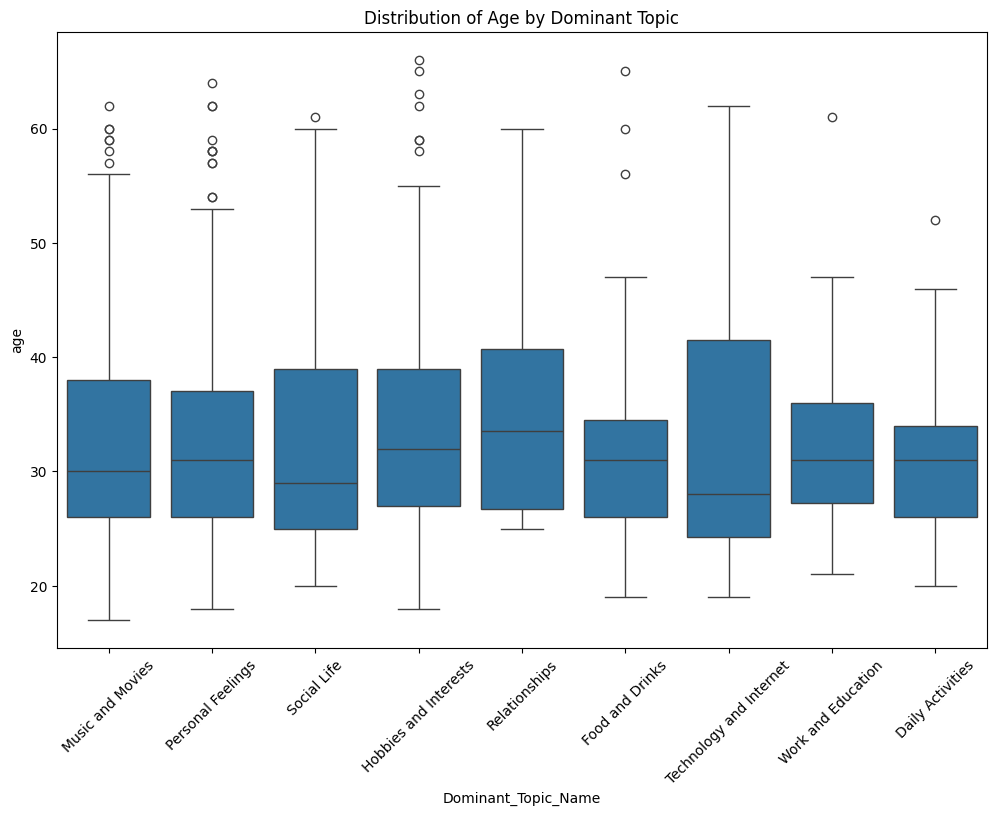

```python
plt.figure(figsize=(12, 8))
sns.boxplot(x='Dominant_Topic_Name', y='age', data=merged_df)
plt.title('Distribution of Age by Dominant Topic')
plt.xticks(rotation=45)
plt.show()
```

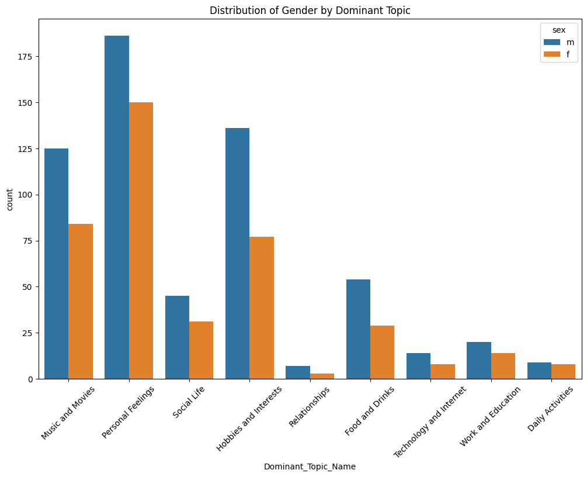

```python
plt.figure(figsize=(12, 8))
sns.countplot(x='Dominant_Topic_Name', hue='sex', data=merged_df)
plt.title('Distribution of Gender by Dominant Topic')
plt.xticks(rotation=45)
plt.show()
```

## Analysis of Topics and Distribution

# Conclusion